# Category Landscape and Pricing Pack Architecture

*Background*

*As in the current slow growth climate, many categories are driving growth primarily through price/mix as volume grows slowly or even declines.* *However taking an annual price raise is not so easy, with consumer transparency into market prices, cost cutting, and commodity shifts.* *While, even simple, sustainable innovation has always served as a means to drive healthy premiums across CPG categories.*

**Category Landscape**

1. 整个品类在什么状况
2. 有哪些重点的细分品类
3. 细分品类的特点
- Sales Value Stable
- Sales Volume Decreasing
- #SKU increasing
- Category Premiumization and Trade Up

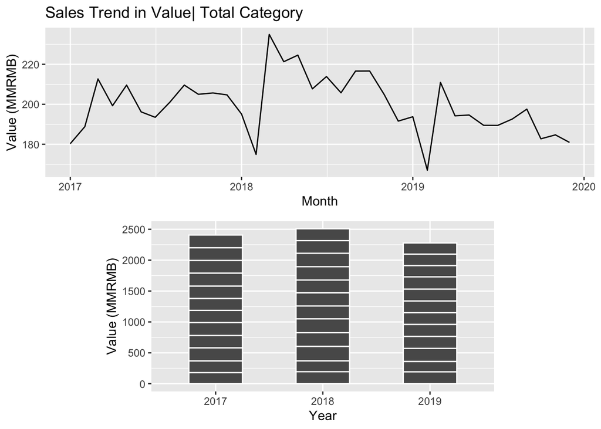

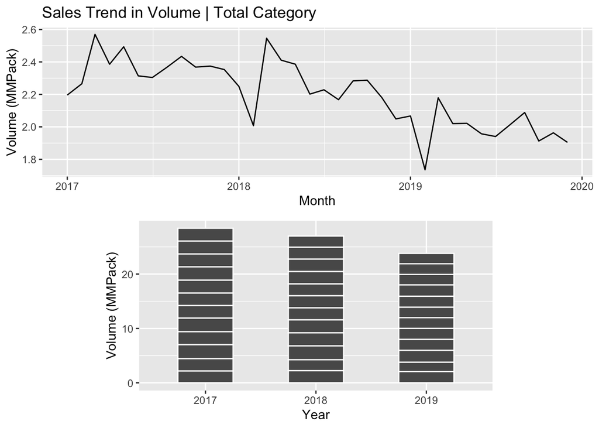

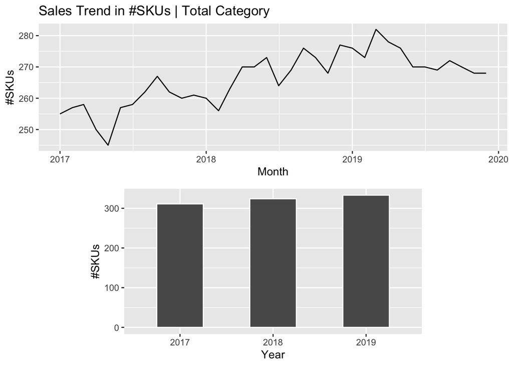

- 三年持续在涨价

[figure not shown]

- 50元以内低端，50-130元中端，130-280中高端，280+高端

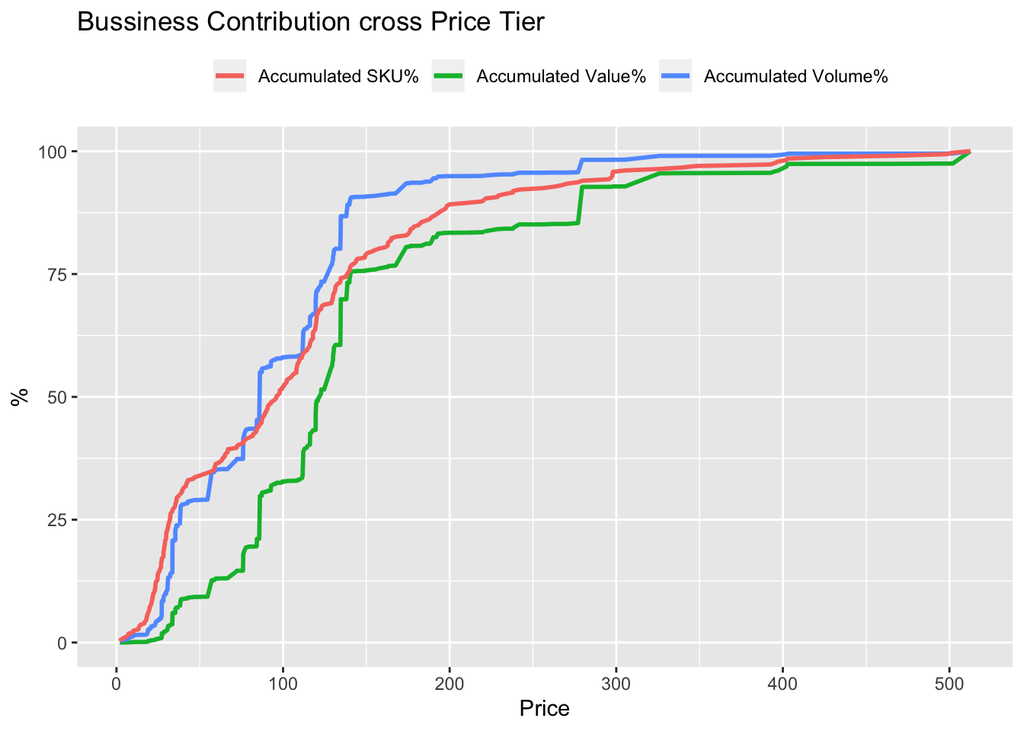

- Coated Tablet 和 Health food 在涨
- Pregnant 和 Geriatric明显在涨价

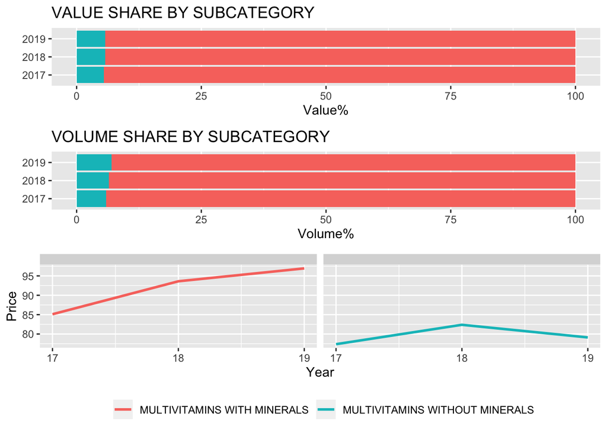

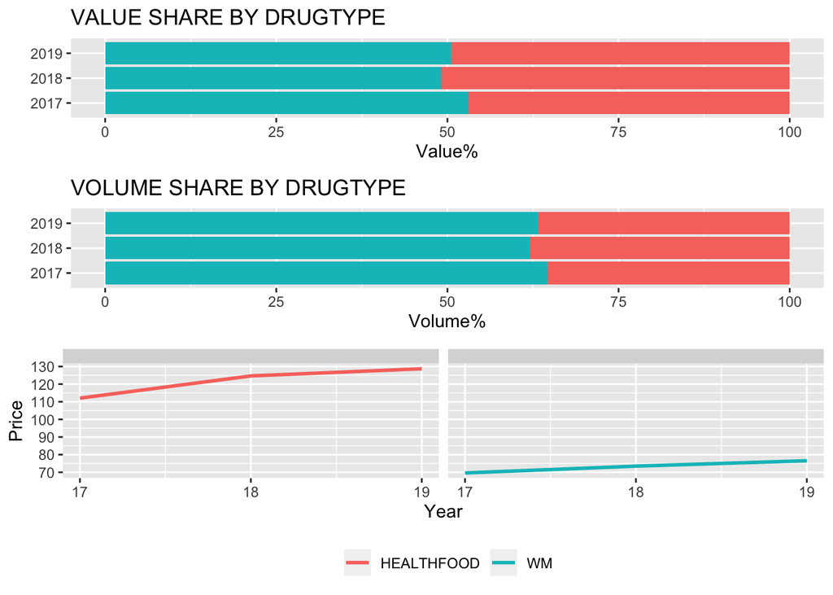

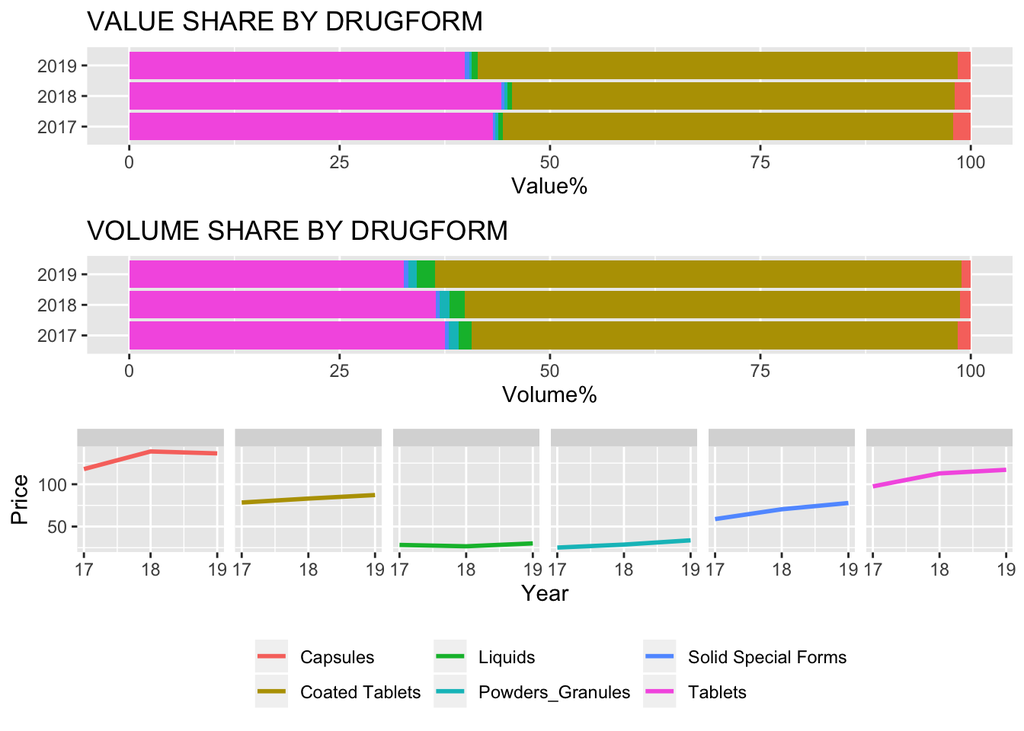

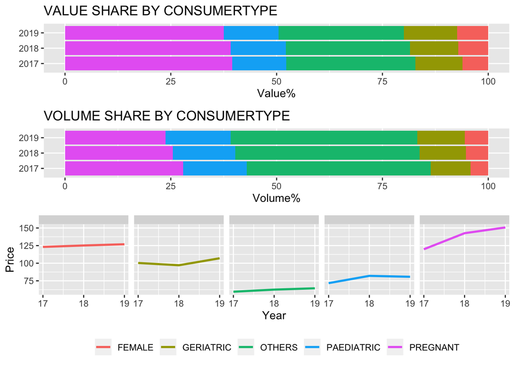

**Players in the market**

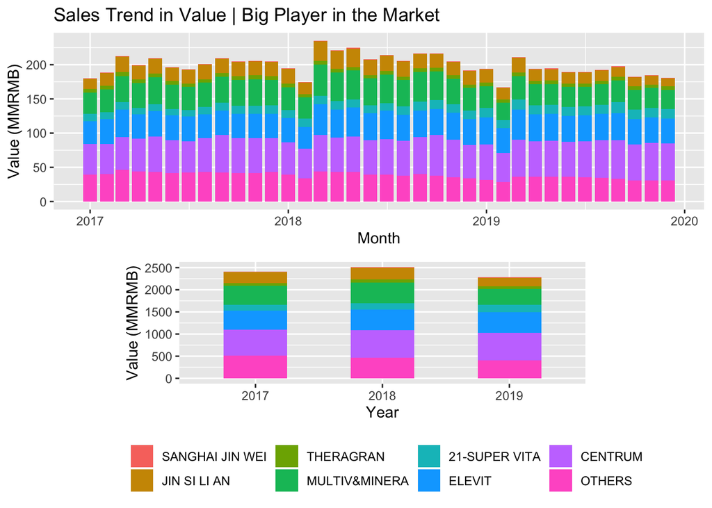

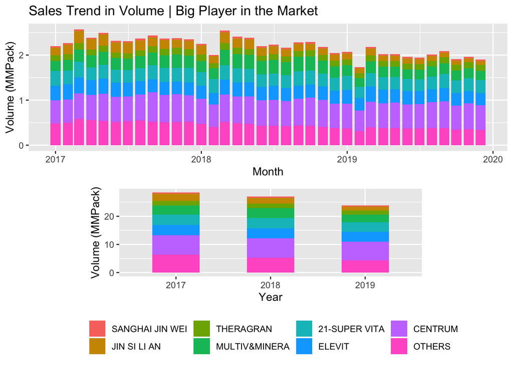

- market share 来看，大家的分布基本平衡

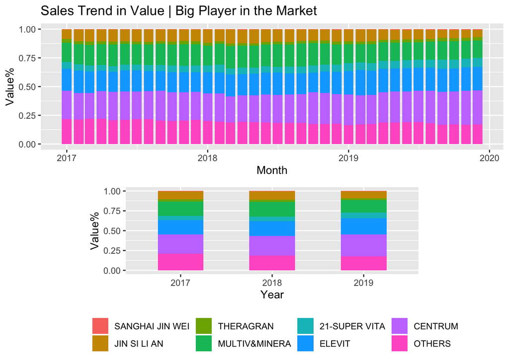

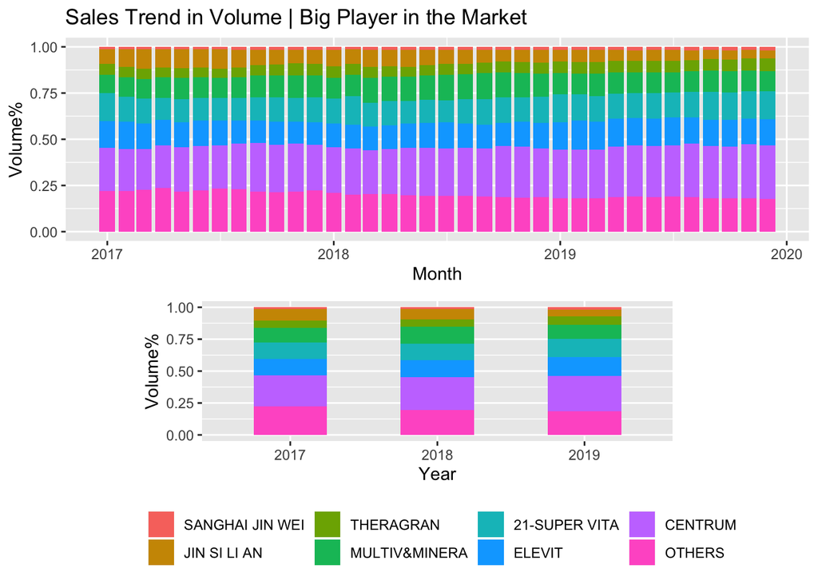

- 善存一个distribution能卖出去更多的sales revenue意味着更高的brand awareness。
- 不考虑price 的因素，这一awareness与其他品牌的差异更大。

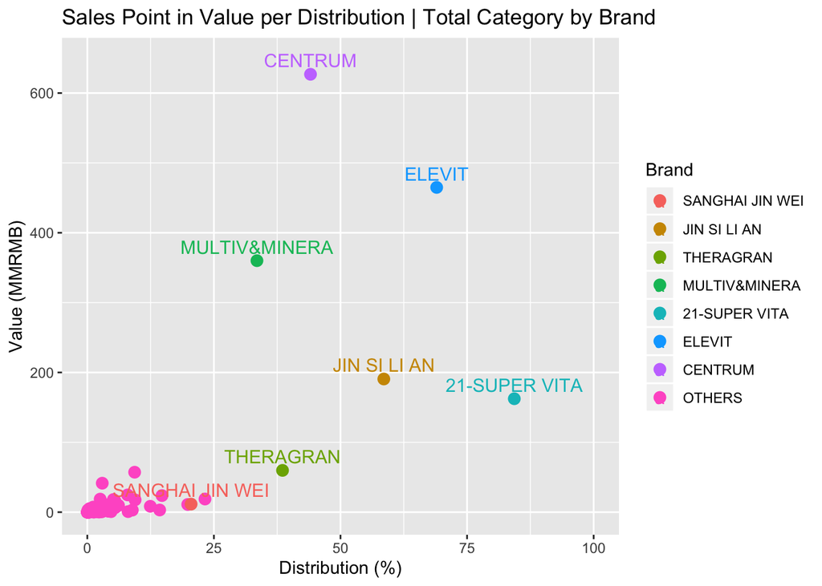

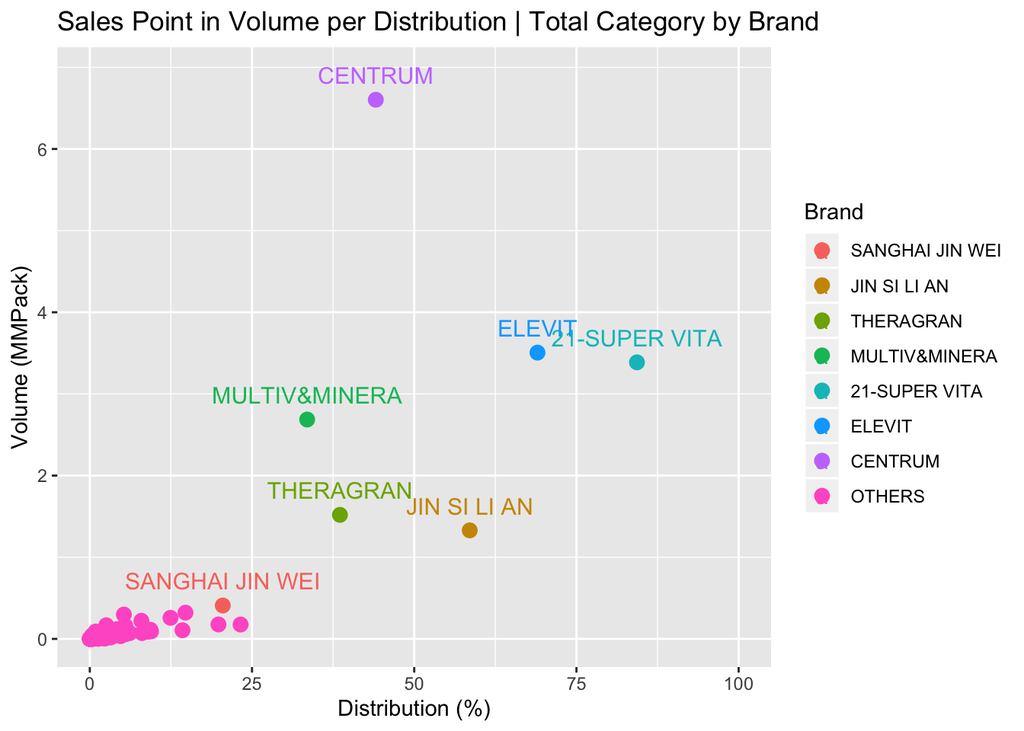

- 全品类百分之七十五的销售额来自于150元以内的产品。
- 全品类百分之八十的销售额来自于200元以内的产品。
- 善存定位在中端产品。

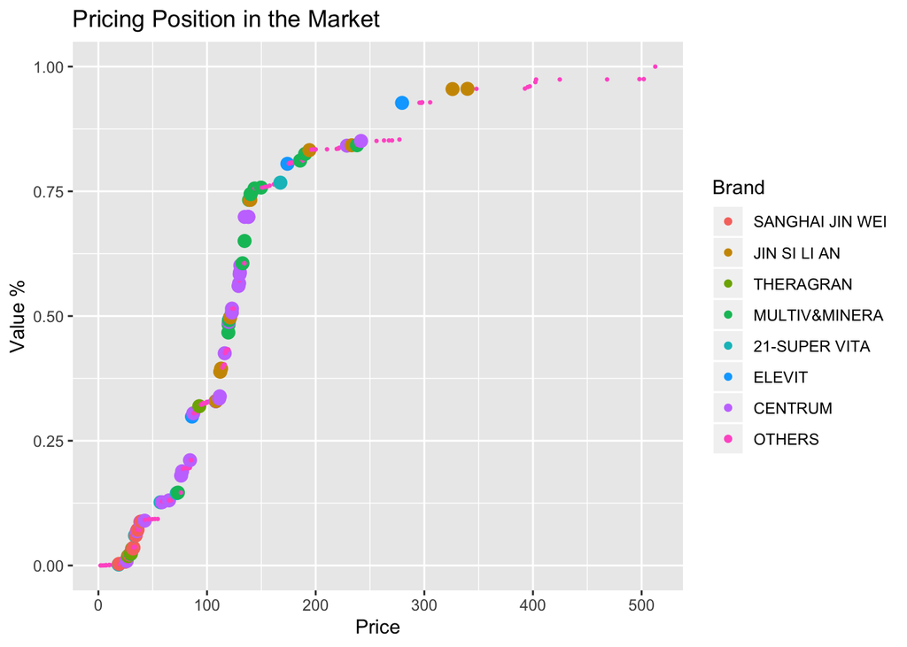

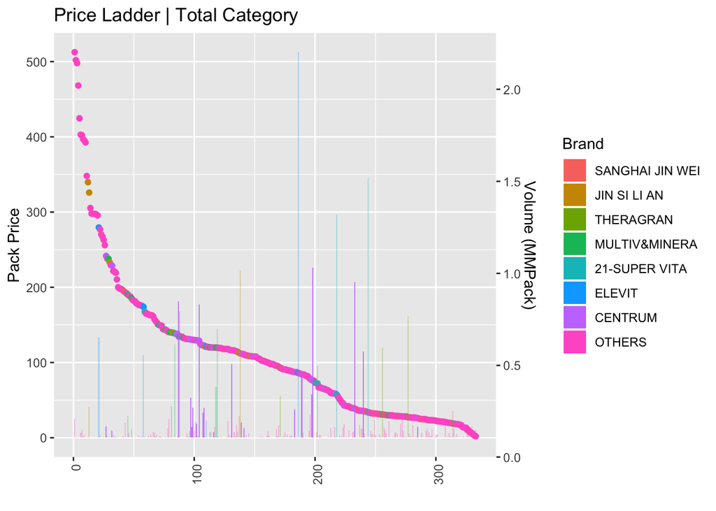

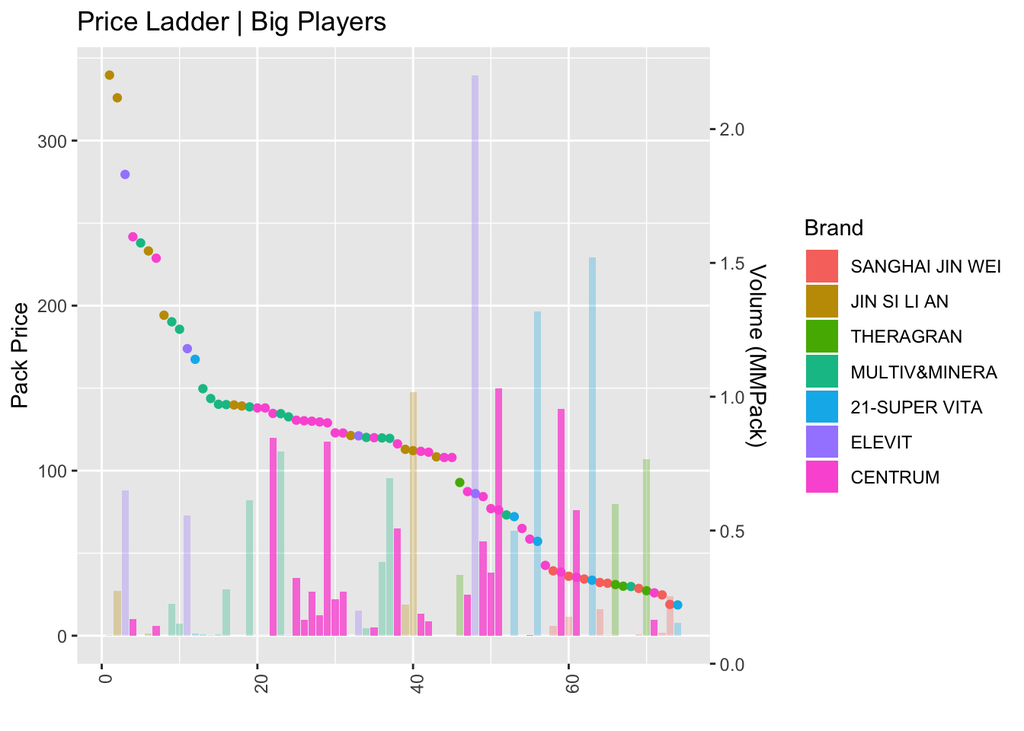

- 善存在老年人市场比较强势(88%)，几乎没有竞争对手
- 百分之42的Coated Tablets市场被善存占据
- 39%的general drugform被善存占据，以及35%的western medicine

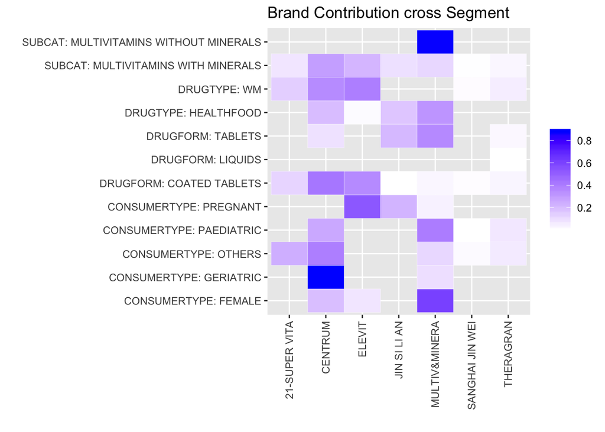

**Centrum**

1. 善存有哪些产品
2. 我们覆盖哪些细分市场，这些细分市场我们在什么位置
3. 这些细分市场，我们有什么机会
- 善存的产品线分散的比较合理，对于每个subbrand在每个价格阶段都有占据
- Silver Centrum MVI 104比80便宜

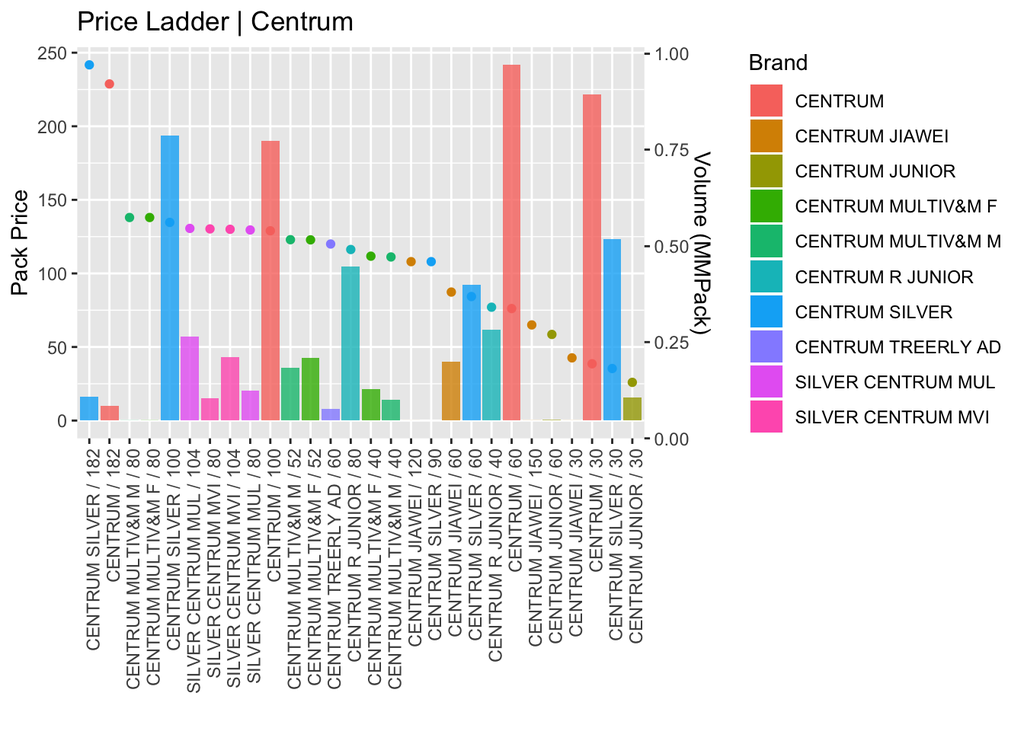

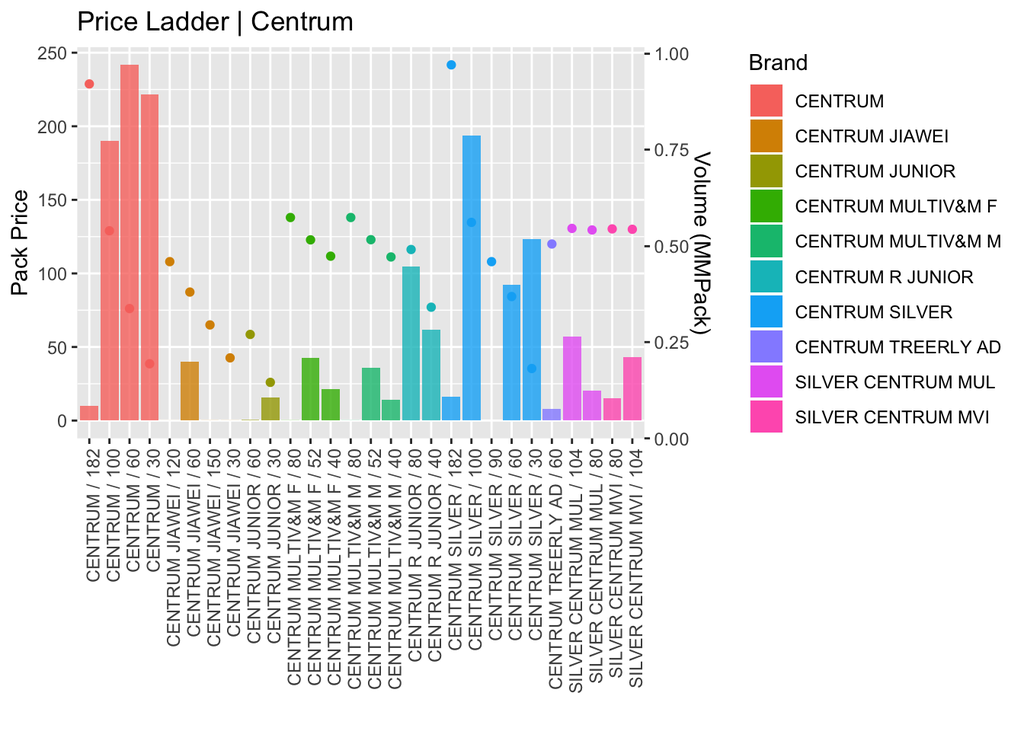

- Silver是一款针对老年人

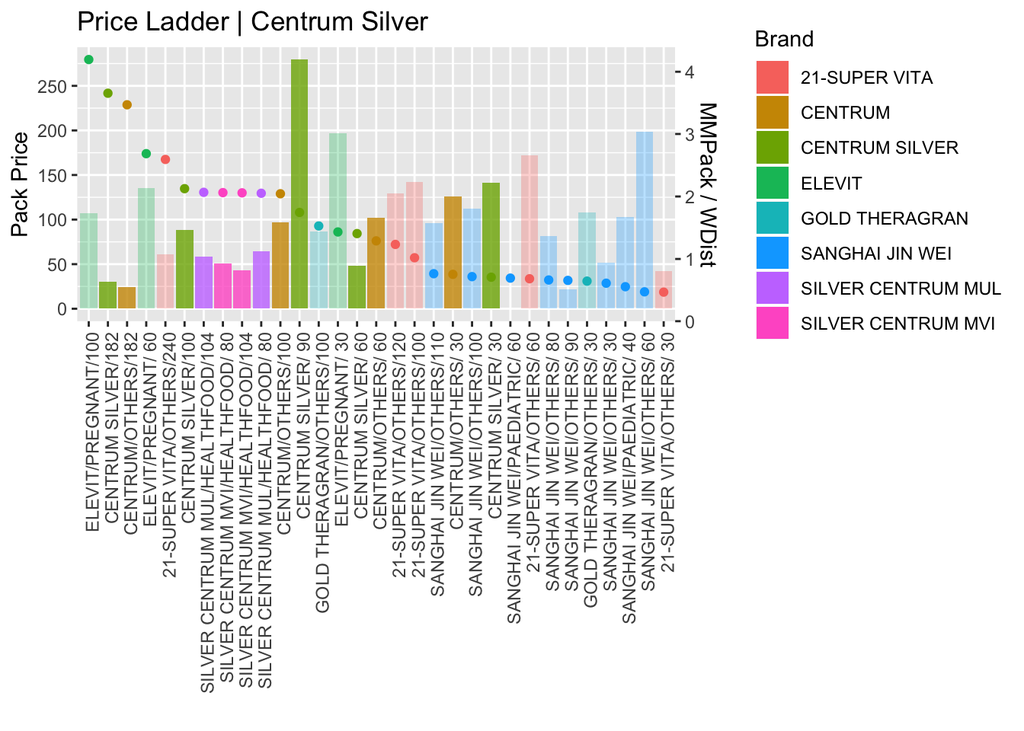